# Metacommunity dynamics and the spurious detection of species associations in co-occurrence analyses (supporting code)

Vincent Calcagno, Nik Cunniffe, Frederic Hamelin

21 December 2021

## Initialisation

Before running, clear the environment, load the packages for plotting and for various other intermediate calculations, load the genMeta functions, set a random seed for reproducibility and set global options

```r
rm(list=ls())

# load dependencies
library(RColorBrewer)
library(fields)
library(Hmsc)
library(snow)
library(corrplot)

# load our library (note this depends on EcoSimR and cubature, so they must be installed too)
source("generalisedMetapopulations.R")

rngSeed <- 1

set.seed(20210109,
         sample.kind = "Rounding")

sigThresh <- 0.05     # threshold p-value for significance testing
resortSpp <- TRUE     # resort the species in order of fastness for presentation?
regularDist <- TRUE   # if this is TRUE, take non-disturbed species regularly-spaced along gradient of fastness

testRun <- FALSE       # if FALSE then do a full length run, otherwise a short one for testing

if(!testRun)
{
  thin <- 100           # for the Hmsc fits
  samples <- 500        # for the Hmsc fits
  nChains <- 4          # for the Hmsc fits
  simReps <- 5000       # for the Gotelli algorithms
  burnInReps <- 1000    # for the Gotelli algorithms
}else{
  thin <- 5             # for the Hmsc fits
  samples <- 10         # for the Hmsc fits
  nChains <- 2          # for the Hmsc fits
  simReps <- 50         # for the Gotelli algorithms
  burnInReps <- 10      # for the Gotelli algorithms
}
```

## Set up the parameters controlling the synthetic community

```r
nSpp <- 31            # number of species
X <- 20               # maximum age of a patch
mu <- 0.2             # patch disturbance rate (assumed constant here. Can be set to 0.1 to reproduce article results)
vM <- rep(0,nSpp)     # migration rate from an external source (fixed to zero here)

r0 <- runif(nSpp,min=1.5,max=3)
vA <- numeric(nSpp)     # asymtotic prevalence of species (i.e. in a patch that has reached a very large age without experiencing disturbance)
vE <- numeric(nSpp)     # extinction rate
vC <- numeric(nSpp)     # colonisation rate
for(i in 1:length(r0))
{
  vA[i] <- runif(1,min=(1-1/r0[i]),max=1)
  vC[i] <- r0[i]*vA[i]*mu / (r0[i]*(vA[i]-1)+1)
  vE[i] <- vC[i] / r0[i] - mu
}

nPatches <- 1000        # can be set to 300, 500 or 1500 to reproduce article results
```

## Interact with the genMeta library and sample the patch occupancy matrices

This calls our library to do the calculations and take samples, as well as to run the sim9 algorithm (Gotelli, Hart, and Ellison (2015)).

```r
set.seed(rngSeed,sample.kind = "Rounding")
m <- createModel(intTol=1e-10)
m <- initParameters(m,nSpp,vM,vC,vE)
m <- initPatchDeath(m,maxAge=X,r=mu)
m <- doCalculations(m)
l <- sampleCommunityMatrix(m,nPatches)
c <- l$cMatrix
# cache patch matrix and ages for use later
patchMatrixCache <- c
patchAgeCache <- l$patchAges
modelCache <- m
```

## Reorder species by fastness, and introduce some species which are never disturbed

```r
#
# Resort species in order of "fastness" for presentation if necessary
#
numNonDisturb <- 6
sppOrder <- 1:nSpp
if(resortSpp)
{
  sppOrder <- order(m$modelCalculations$vVariance)
}
# sample non-disturbed species entirely randomly
vNonDisturb <- rep(FALSE,nSpp)
disturbSpp <- sample(1:nSpp,numNonDisturb)
vNonDisturb[disturbSpp] <- TRUE
if(regularDist) # if desired, take the non-disturbed species to be regularly spaced
{
  vNonDisturb <- rep(FALSE,nSpp)
  fstIDX <- (0:(numNonDisturb-1))*floor((nSpp/numNonDisturb)) + 2
  disturbSpp <- numeric(numNonDisturb)
  for(i in 1:length(fstIDX))
  {
    disturbSpp[i] <- sppOrder[fstIDX[i]]
  }
  vNonDisturb[disturbSpp] <- TRUE
}
```

This resamples the community matrix, but then alters it to account for the idea of a subset of species never being disturbed, then redoes the sim9 calculations. Note again that information is cached, to allow these calculations to be redone using sim2 later.

```r
# update the calculation matrix to reflect idea some patches are not valid
minVar <- min(m$modelCalculations$vVariance)
m$modelCalculations$vA[disturbSpp] <- NA
m$modelCalculations$vR[disturbSpp] <- NA
for(i in disturbSpp)
{
  m$modelCalculations$mCovariance[i,1:nSpp] <- NA
  m$modelCalculations$mCovariance[1:nSpp,i] <- NA
}
# make sure these come out as having smallest variance in any later sorting
# note a negative "variance" is okay, since all are relative to the average
m$modelCalculations$vVariance[disturbSpp] <- minVar-1
# alter the patch matrix to reflect non-disturbed patches
for(s in disturbSpp)
{
  roots <- Re(polyroot(c(vM[s],(vC[s]-vM[s]-vE[s]),-vC[s])))
  # the structure of the model means there can only ever be a single positive root
  w <-  which(roots>0)
  new_pi <- roots[w]
  print(paste("Species", s, "-> Species", which(sppOrder==s), "in sorted order ->", new_pi))
  c[,s] <- rbinom(nPatches,1,new_pi)
}
```

```
## [1] "Species 29 -> Species 2 in sorted order -> 0.486587291877229"
## [1] "Species 13 -> Species 7 in sorted order -> 0.728897455146208"
## [1] "Species 24 -> Species 12 in sorted order -> 0.790852808696515"
## [1] "Species 5 -> Species 17 in sorted order -> 0.967659562195392"
## [1] "Species 3 -> Species 22 in sorted order -> 0.810096782907662"
## [1] "Species 23 -> Species 27 in sorted order -> 0.874675546029401"
```

```r
p <- initPairwise(c)
p <- simPairwise(p,simReps,burnInReps,TRUE)
pDistCached <- p
# cache patch matrix and ages for use later
patchMatrixCacheImmune <- c
patchAgeCacheImmune <- l$patchAges
modelCacheImmune <- m
# And now reset back to the original state for first set of calculations
c <- patchMatrixCache
m <- modelCache
```

## Species occupancy curves (Fig. 3A)

We now have all the required information to plot out the species occupancy curves (marking those which will be unperturbed in later figures by colouring them grey).

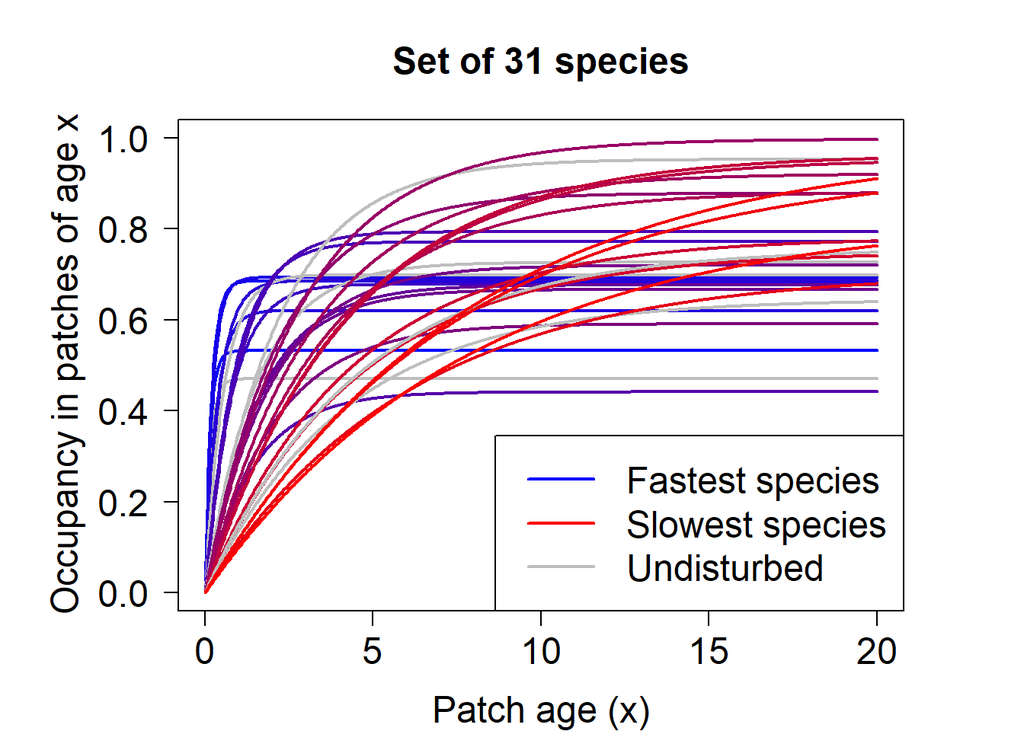

```r
par(mfrow=c(1,1))
colfunc <- colorRampPalette(c("blue","red"))
vCol <- colfunc(nSpp)
par(las=1)
par(mar=c(4.1, 6.1, 4.1, 4.1))
for(i in 1:nSpp)
{
  thisI <- sppOrder[i]

  R_i <- vM[thisI]+vC[thisI]*m$modelCalculations$vP[thisI]+vE[thisI]
  A_i <- (vM[thisI]+vC[thisI]*m$modelCalculations$vP[thisI])/R_i

  x<-seq(0,20,length.out=1000)
  p_ix <- A_i*(1-exp(-R_i*x))

  thisCol <- vCol[i]
  if(thisI %in% disturbSpp)
  {
    thisCol <- "grey"
  }
  if(i==1)
  {
    yLab <- expression(paste("Occupancy in patches of age x"))

    plot(x,
         p_ix,
         ylim=c(0,1),
         ty="l",
         col=thisCol,
         xlab="Patch age (x)",
         ylab=yLab,
         main="Set of 31 species",
         lwd=2,
         cex.lab=1.5,
         cex.axis=1.5,
         cex.main=1.5)
  }else
  {
    lines(x,
          p_ix,
          col=thisCol,
          lwd=2)
  }
}
legend("bottomright",
       c("Fastest species","Slowest species","Undisturbed"),
       col=c("blue","red","grey"),
       lty=1,
       lwd=2,
       cex=1.5)
```

## Pairwise covariances of relative distribution profiles (Figure 3B)

This calculates the pairwise covariance for species pairs, and stores it after subtracting the average variance. This is then plotted. The loop below also calculates the p-value for the Fisher exact test for all pairs of species, since that is needed later

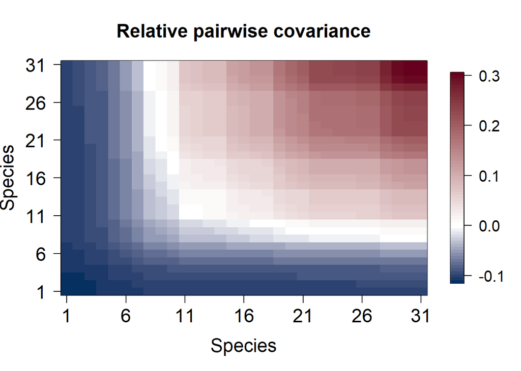

```r
p <- initPairwise(c)
p <- simPairwise(p,simReps,burnInReps,TRUE)
# cache the state of p just before calling the Gotelli algorithm, so can be redone using sim2 later
pOrigCache <- p
#
# Variance relative to average and Fisher's exact test
#
predToPlot <- matrix(NA,nrow=nSpp,ncol=nSpp)
pValToPlot <- matrix(NA,nrow=nSpp,ncol=nSpp)
pairwiseCovar <- numeric(nSpp*(nSpp-1)/2)
fisherP <- numeric(nSpp*(nSpp-1)/2)
thisIDX <- 0
for(i in 1:nSpp)
{
  for(j in 1:nSpp)
  {
    predToPlot[which(sppOrder==i),which(sppOrder==j)] <- m$modelCalculations$mCovariance[i,j] - m$modelCalculations$averageFastness
    if(i < j)
    {
      int <- c[,i] + c[,j]
      bothSpp <- sum(c[,i]&c[,j])
      noSpp <- sum(!(c[,i]|c[,j]))
      onlyI <- sum(c[,i])-bothSpp
      onlyJ <- sum(c[,j])-bothSpp

      thisData <- matrix(c(noSpp,onlyI,onlyJ,bothSpp),
                         nrow=2,
                         dimnames = list(SppI = c("N","Y"),
                                         SppJ = c("N","Y")))

      f <- fisher.test(thisData)

      pValToPlot[which(sppOrder==i),which(sppOrder==j)] <- f$p.value
      pValToPlot[which(sppOrder==j),which(sppOrder==i)] <- f$p.value

      thisIDX <- thisIDX + 1
      fisherP[thisIDX] <- f$p.value
      pairwiseCovar[thisIDX] <- m$modelCalculations$mCovariance[i,j] - m$modelCalculations$averageFastness
    }
  }
}
fisherPAdj <- p.adjust(fisherP, method = "fdr")

minVal <- min(predToPlot)
# ensure legend bar has a full set of labels
if(minVal > -0.1)
{
  minVal <- -0.1
}
maxVal <- max(predToPlot)
absMinVal <- abs(minVal)

if(absMinVal > maxVal)
{
  minNum <- 50
  maxNum <- ceiling((maxVal/absMinVal)*minNum)
}else{
  maxNum <- 50
  minNum <- ceiling((absMinVal/maxVal)*maxNum)
}

cols = rev(brewer.pal(11,'RdBu'))
rc1 <- colorRampPalette(colors = c(cols[1], "white"), space = "Lab")(minNum)
rc2 <- colorRampPalette(colors = c("white", cols[11]), space = "Lab")(maxNum)

rampcols <- c(rc1, rc2)

par(xpd=NA)
par(las=1)
image.plot(1:nSpp,
           1:nSpp,
           predToPlot,
           main="Relative pairwise covariance",
           xlab="Species",
           ylab="Species",
           xaxt="n",
           yaxt="n",
           col=rampcols,
           cex.lab=1.5,
           cex.axis=1.5,
           cex.main=1.5,
           axis.args = list(cex.axis = 1.25))
axis(1, seq(1,nSpp,5),las=1,cex.axis=1.5)
axis(2, seq(1,nSpp,5),las=2,cex.axis=1.5)
```

## Pairwise Fisher’s tests of association (Figure 4)

Plot out the logit of the (fdr corrected) p-values for the Fisher exact test as a function of pairwise covariance

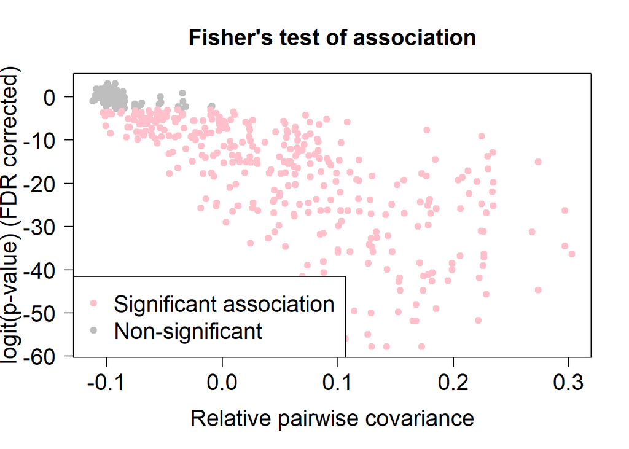

```r
logit <- function(x)
{
  return(log(x)-log(1-x))
}

par(fig = c(0,1,0,1))
par(las=1)
plot(pairwiseCovar,
     logit(fisherPAdj),
     xlab="Relative pairwise covariance",
     ylab="logit(p-value) (FDR corrected)",
     main="Fisher's test of association",
     cex.axis=1.5,
     cex.main=1.5,
     cex.lab=1.5,
     pch=20,
     cex=1.5,
     col="grey")
points(pairwiseCovar[which(fisherPAdj<sigThresh)],
       logit(fisherPAdj[which(fisherPAdj<sigThresh)]),
       pch=20,
       cex=1.5,
       col="pink")
legend("bottomleft",#x=-0.1,y=-45,
       c("Significant association","Non-significant"),
       pch=20,
       cex=1.5,
       col=c("pink","grey"),
       ncol=1)
```

## Pairwise Fisher’s tests of association (alternate plot)

Show which Fisher exact tests give a significant result in the matrix showing pairs of species

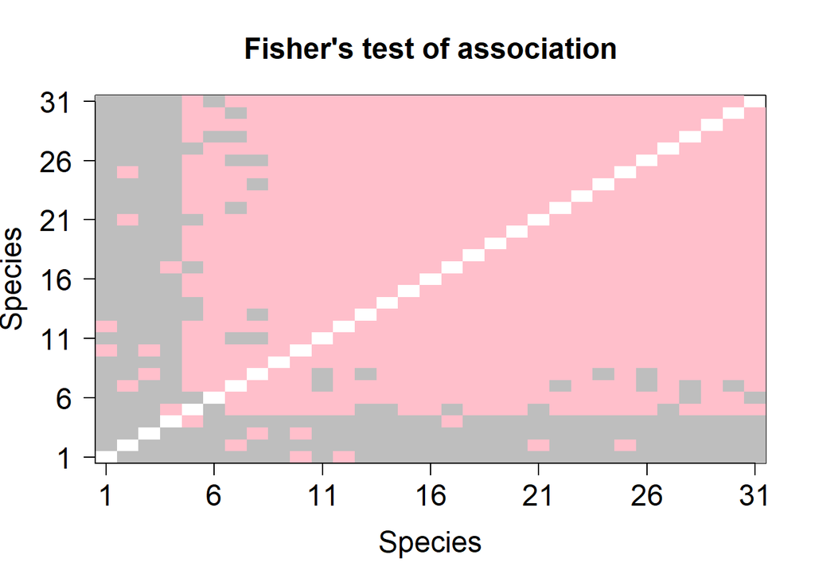

```r
par(xpd=NA)
par(las=1)
pValToPlotFDR <- matrix(p.adjust(pValToPlot, method = "fdr"),nrow=nSpp)
twoColours <- colorRampPalette(colors = c("grey", "pink"), space = "Lab")(2)
image(1:nSpp,
      1:nSpp,
      (pValToPlotFDR<sigThresh),
      main="Fisher's test of association",
      xlab="Species",
      ylab="Species",
      xaxt="n",
      yaxt="n",
      col=twoColours,
      cex.lab=1.5,
      cex.axis=1.5,
      cex.main=1.5)
axis(1, seq(1,nSpp,5),las=1,cex.axis=1.5)
axis(2, seq(1,nSpp,5),las=2,cex.axis=1.5)
```

```r
print(paste("Pink =", sum(pValToPlotFDR<sigThresh,na.rm=T),"Grey =", sum(pValToPlotFDR>=sigThresh,na.rm=T),"Total =", sum(!is.na(pValToPlotFDR))))
```

```
## [1] "Pink = 686 Grey = 244 Total = 930"
```

## Pairwise association via null model analysis (fixed-fixed, or sim9, Figure 5)

This shows which tests based on sim9 lead to significant results for facilitation and competition, colour coding them in the species matrix

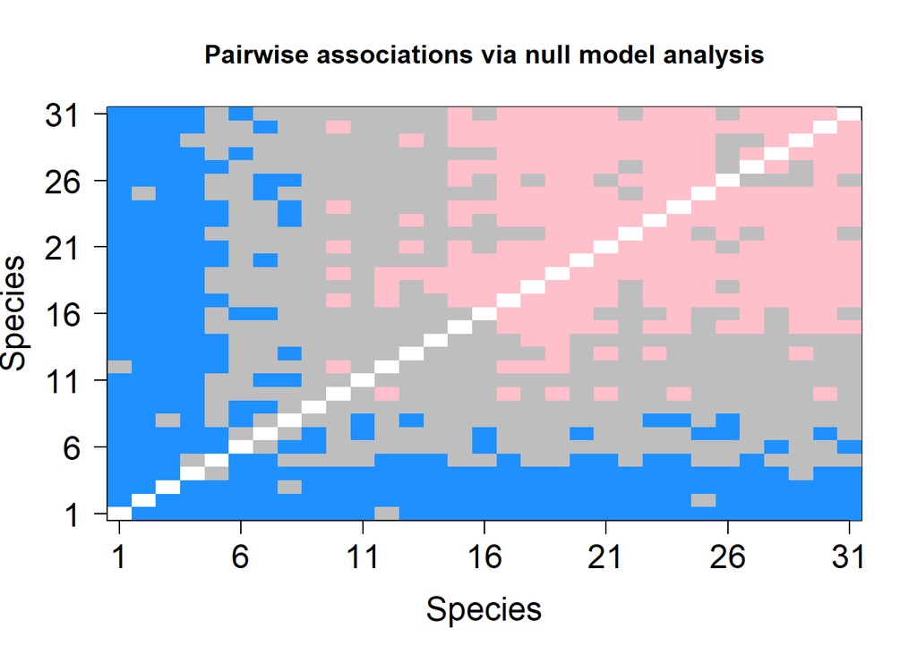

```r
pSigMatrix <- matrix(0,nrow=nSpp,ncol=nSpp)
for(i in 1:p$speciesPairs$nPairs)
{
  spOne <- p$speciesPairs$allSppOne[i]
  spTwo <- p$speciesPairs$allSppTwo[i]

  if(p$output$pHighAdj[i] < sigThresh)
  {
    pSigMatrix[which(sppOrder==spOne),which(sppOrder==spTwo)] <- 1
    pSigMatrix[which(sppOrder==spTwo),which(sppOrder==spOne)] <- 1
  }
  if(p$output$pLowAdj[i] < sigThresh)
  {
    pSigMatrix[which(sppOrder==spOne),which(sppOrder==spTwo)] <- -1
    pSigMatrix[which(sppOrder==spTwo),which(sppOrder==spOne)] <- -1
  }
}
for(i in 1:nSpp)
{
  pSigMatrix[i,i] <- NA
}
threeColours <- colorRampPalette(colors = c("pink","grey","dodgerblue"), space = "Lab")(3)
image(1:nSpp,
      1:nSpp,
      pSigMatrix,
      main="Pairwise associations via null model analysis",
      xlab="Species",
      ylab="Species",
      xaxt="n",
      yaxt="n",
      col=threeColours,
      cex.lab=1.5,
      cex.axis=1.5,
      zlim=c(-1,1))
axis(1, seq(1,nSpp,5),las=1,cex.axis=1.5)
axis(2, seq(1,nSpp,5),las=2,cex.axis=1.5)
```

```r
print(paste("Pink =", sum(pSigMatrix==-1,na.rm=T),"Grey =" , sum(pSigMatrix==0,na.rm=T),"Blue =",sum(pSigMatrix==1,na.rm=T),"Total =",sum(!is.na(pSigMatrix))))
```

```
## [1] "Pink = 256 Grey = 400 Blue = 274 Total = 930"
```

## Pairwise association via null model analysis (fixed-fixed, or sim9, Figure 5) when some species are immune

This shows which tests based on sim9 lead to significant results for facilitation and competition, colour coding them in the species matrix, this time with a set of species undisturbed

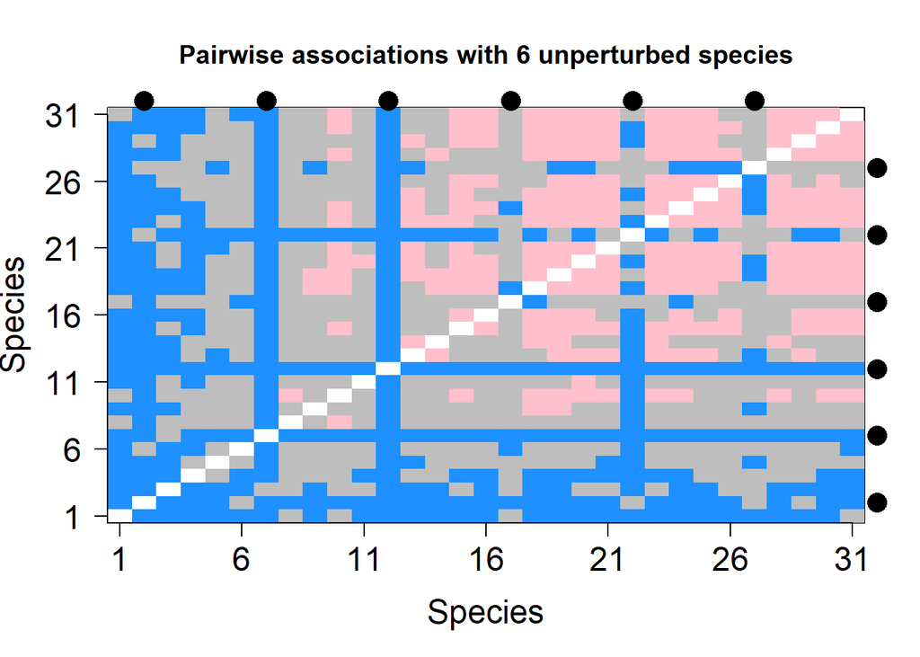

```r
# reload the cached versions from the top
p <- pDistCached
c <- patchMatrixCacheImmune
m <- modelCacheImmune
# now do the calculations
pSigMatrix2 <- matrix(0,nrow=nSpp,ncol=nSpp)
for(i in 1:p$speciesPairs$nPairs)
{
  spOne <- p$speciesPairs$allSppOne[i]
  spTwo <- p$speciesPairs$allSppTwo[i]

  if(p$output$pHighAdj[i] < sigThresh)
  {
    pSigMatrix2[which(sppOrder==spOne),which(sppOrder==spTwo)] <- 1
    pSigMatrix2[which(sppOrder==spTwo),which(sppOrder==spOne)] <- 1
  }
  if(p$output$pLowAdj[i] < sigThresh)
  {
    pSigMatrix2[which(sppOrder==spOne),which(sppOrder==spTwo)] <- -1
    pSigMatrix2[which(sppOrder==spTwo),which(sppOrder==spOne)] <- -1
  }
}
for(i in 1:nSpp)
{
  pSigMatrix2[i,i] <- NA
}
threeColours <- colorRampPalette(colors = c("pink","grey","dodgerblue"), space = "Lab")(3)
image(1:nSpp,
      1:nSpp,
      pSigMatrix2,
      main=paste("Pairwise associations with",numNonDisturb,"unperturbed species"),
      xlab="Species",
      ylab="Species",
      xaxt="n",
      yaxt="n",
      col=threeColours,
      cex.lab=1.5,
      cex.axis=1.5,
      zlim=c(-1,1))
axis(1, seq(1,nSpp,5),las=1,cex.axis=1.5)
axis(2, seq(1,nSpp,5),las=2,cex.axis=1.5)
par(xpd=NA)
for(s in disturbSpp)
{
  points(which(sppOrder==s),nSpp+1,pch=16,cex=2)
  points(nSpp+1,which(sppOrder==s),pch=16,cex=2)
}
```

```r
print(paste("Pink =",sum(pSigMatrix2==-1,na.rm=T),"Grey =",sum(pSigMatrix2==0,na.rm=T),"Blue =",sum(pSigMatrix2==1,na.rm=T),"Total =",sum(!is.na(pSigMatrix2))))
```

```
## [1] "Pink = 218 Grey = 384 Blue = 328 Total = 930"
```

And finally make a nice legend for the figure

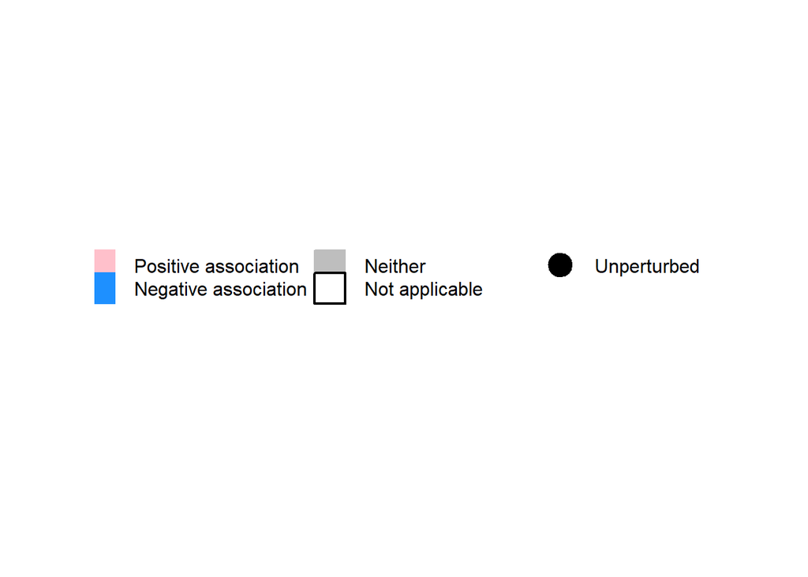

```r
plot.new()
myL <- legend(x="center",
              cex=1.0,
              #cex=1.5,
              c("Positive association","Negative association","Neither","Not applicable","Unperturbed"),
              bty="n",
              col=c("pink","dodgerblue","grey","black","black"),
              lty=c(NA,NA,NA,NA),
              lwd=c(NA,NA,NA,2),
              pt.bg = c("pink","dodgerblue","grey","white","black"),
              pch=c(22,22,22,22,20),
              ncol=3,
              pt.cex = 4,
              bg="grey")
```

## Direct tests of pairwise independence through fixed-equiprobable permutations (sim2; Figure 4)

This plots results based on the sim2 algorithm. It uses the cached information in `pOrigCache` from before.

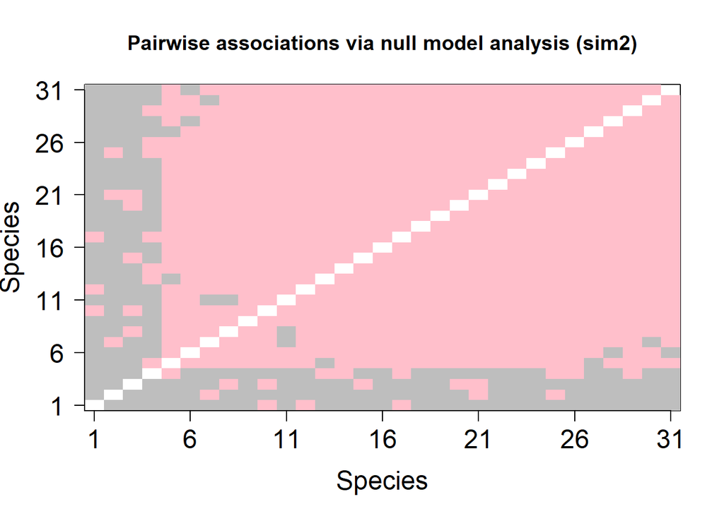

```r
# reset to cached version (i.e without undisturbed species)
pII <- simPairwise(pOrigCache,simReps,burnInReps,FALSE)
pSigMatrix <- matrix(0,nrow=nSpp,ncol=nSpp)
for(i in 1:pII$speciesPairs$nPairs)
{
  spOne <- pII$speciesPairs$allSppOne[i]
  spTwo <- pII$speciesPairs$allSppTwo[i]

  if(pII$output$pHighAdj[i] < sigThresh)
  {
    pSigMatrix[which(sppOrder==spOne),which(sppOrder==spTwo)] <- 1
    pSigMatrix[which(sppOrder==spTwo),which(sppOrder==spOne)] <- 1
  }
  if(pII$output$pLowAdj[i] < sigThresh)
  {
    pSigMatrix[which(sppOrder==spOne),which(sppOrder==spTwo)] <- -1
    pSigMatrix[which(sppOrder==spTwo),which(sppOrder==spOne)] <- -1
  }
}
for(i in 1:nSpp)
{
  pSigMatrix[i,i] <- NA
}
threeColours <- colorRampPalette(colors = c("pink","grey","dodgerblue"), space = "Lab")(3)
image(1:nSpp,
      1:nSpp,
      pSigMatrix,
      main="Pairwise associations via null model analysis (sim2)",
      xlab="Species",
      ylab="Species",
      xaxt="n",
      yaxt="n",
      col=threeColours,
      cex.lab=1.5,
      cex.axis=1.5,
      zlim=c(-1,1))
axis(1, seq(1,nSpp,5),las=1,cex.axis=1.5)
axis(2, seq(1,nSpp,5),las=2,cex.axis=1.5)
```

```r
print(paste("Pink =",sum(pSigMatrix==-1,na.rm=T),"Grey =",sum(pSigMatrix==0,na.rm=T),"Blue =",sum(pSigMatrix==1,na.rm=T),"Total =",sum(!is.na(pSigMatrix))))
```

```
## [1] "Pink = 724 Grey = 206 Blue = 0 Total = 930"
```

## Direct tests of pairwise independence through fixed-equiprobable permutations (sim2; Figure 4), with immune species

This plots results based on the sim2 algorithm, with immune species. It uses the cached information in `pDistCached` from before.

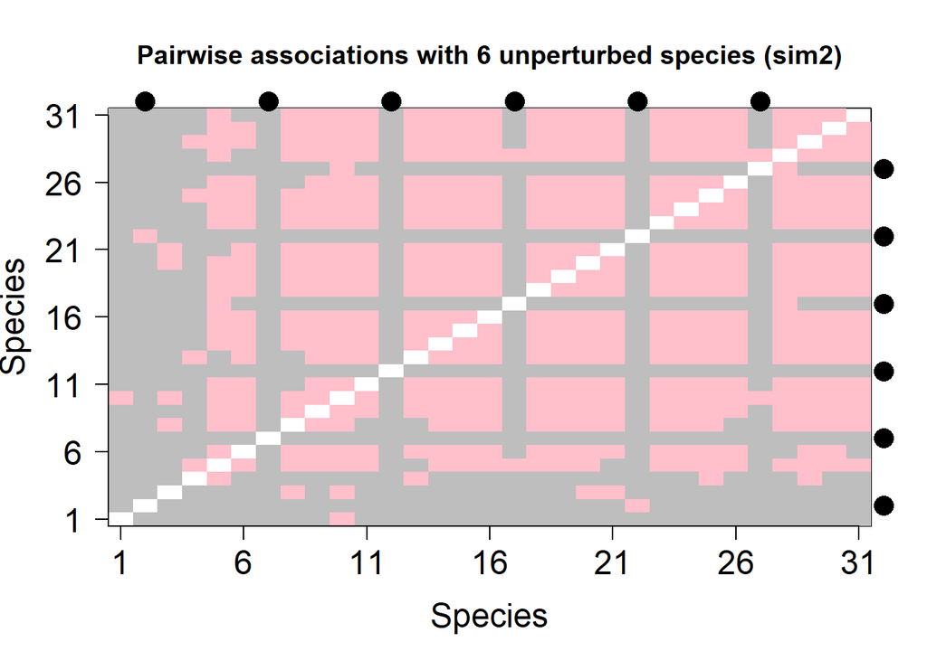

```r
pIII <- simPairwise(pDistCached,simReps,burnInReps,FALSE)
pSigMatrix2 <- matrix(0,nrow=nSpp,ncol=nSpp)
for(i in 1:pIII$speciesPairs$nPairs)
{
  spOne <- pIII$speciesPairs$allSppOne[i]
  spTwo <- pIII$speciesPairs$allSppTwo[i]

  if(pIII$output$pHighAdj[i] < sigThresh)
  {
    pSigMatrix2[which(sppOrder==spOne),which(sppOrder==spTwo)] <- 1
    pSigMatrix2[which(sppOrder==spTwo),which(sppOrder==spOne)] <- 1
  }
  if(pIII$output$pLowAdj[i] < sigThresh)
  {
    pSigMatrix2[which(sppOrder==spOne),which(sppOrder==spTwo)] <- -1
    pSigMatrix2[which(sppOrder==spTwo),which(sppOrder==spOne)] <- -1
  }
}
for(i in 1:nSpp)
{
  pSigMatrix2[i,i] <- NA
}
threeColours <- colorRampPalette(colors = c("pink","grey","dodgerblue"), space = "Lab")(3)
image(1:nSpp,
      1:nSpp,
      pSigMatrix2,
      main=paste("Pairwise associations with",numNonDisturb,"unperturbed species (sim2)"),
      xlab="Species",
      ylab="Species",
      xaxt="n",
      yaxt="n",
      col=threeColours,
      cex.lab=1.5,
      cex.axis=1.5,
      zlim=c(-1,1))
axis(1, seq(1,nSpp,5),las=1,cex.axis=1.5)
axis(2, seq(1,nSpp,5),las=2,cex.axis=1.5)
par(xpd=NA)
for(s in disturbSpp)
{
  points(which(sppOrder==s),nSpp+1,pch=16,cex=2)
  points(nSpp+1,which(sppOrder==s),pch=16,cex=2)
}
```

```r
print(paste("Pink =",sum(pSigMatrix2==-1,na.rm=T),"Grey =",sum(pSigMatrix2==0,na.rm=T),"Blue =",sum(pSigMatrix2==1,na.rm=T),"Total =",sum(!is.na(pSigMatrix2))))
```

```
## [1] "Pink = 476 Grey = 454 Blue = 0 Total = 930"
```

## Joint species distribution modelling ## Using the Hmsc library

Now analyse the (same) patch matrix data, using the Hmsc library (Tikhonov et al. (2021)). We run four different Hmsc models, ranging in complexity from Model 0 that has no environmental covariate or latent factor, to Model 2, that includes patch-age as an environmental covariate. Model 1 controls for patch richness (number of species) as a single latent factor, thereby replicating the philiosophy of the Sim9 permutation algorithm (see Ovaskainen and Abrego (2020)). Model 2’’ is the same as Model 2, except instead of patch-age, patch richness is used.

We run the four models, once on the species co-occurrence matrix without any immune species, and then with six immune species introduced.

The MCMC sampling parameters, tests of convergence, computation of significant species associations, and plots of model fit follow exactly the examples in (Tikhonov et al. (2020)). We reset the seed to unity before any MCMC sampling for replicability. Note that using different seeds (or different MCMC parameters) may slightly change (quantitatively) the outputs. Also note that the computation time can be very long for these (several hours depending on CPUs). For convenience and debugging, setting `testRun <- TRUE` (towards the top of the markdown file) uses a less stringent parameter set, that does not yield satisfying convergence, but that can be run in a couple of minutes.

[output not shown]

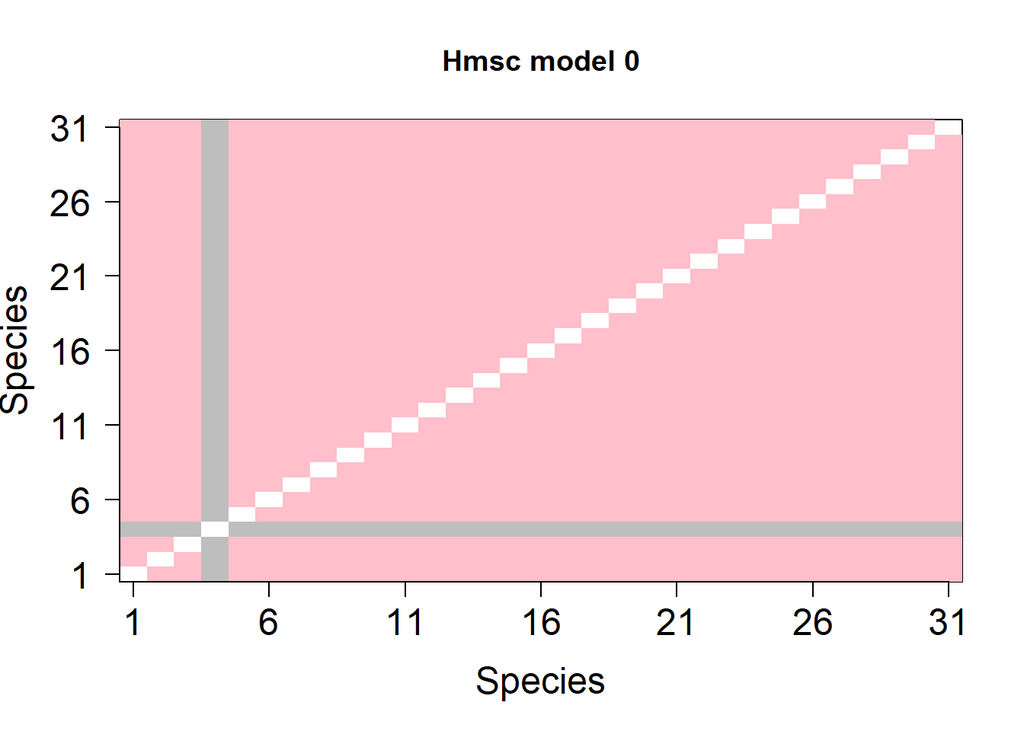

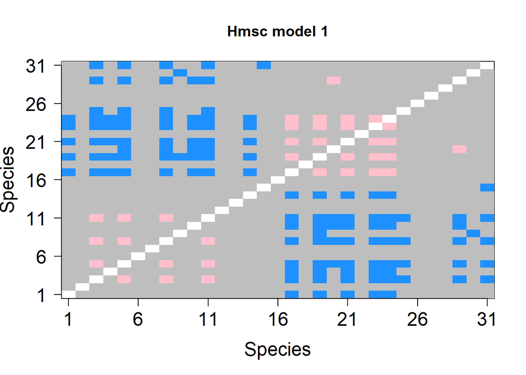

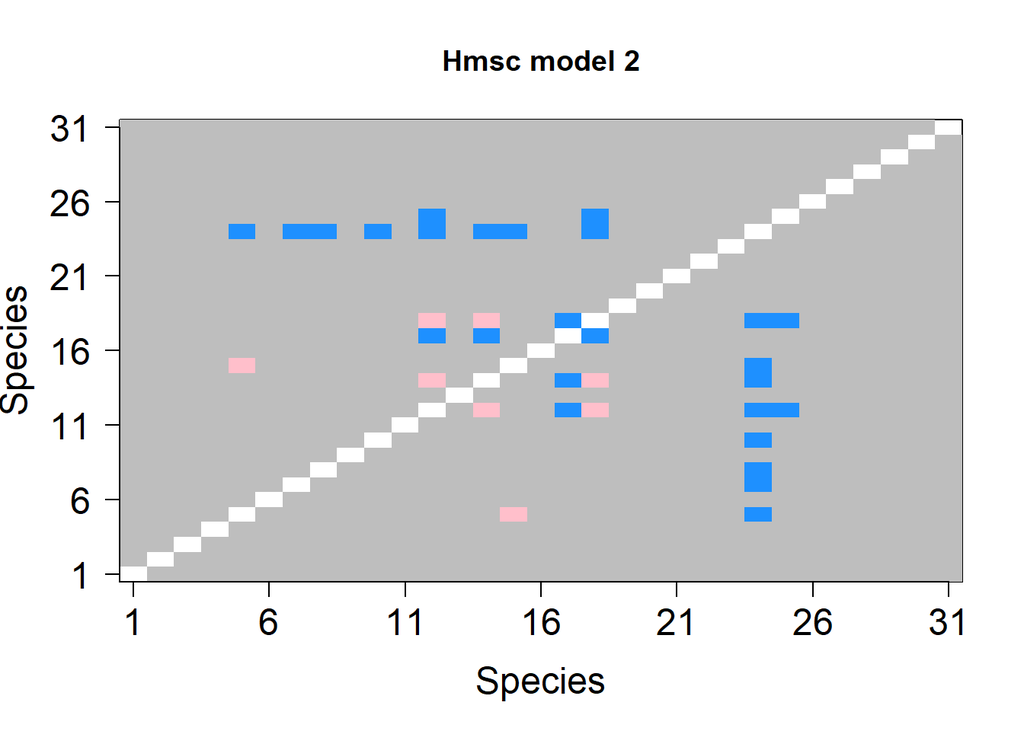

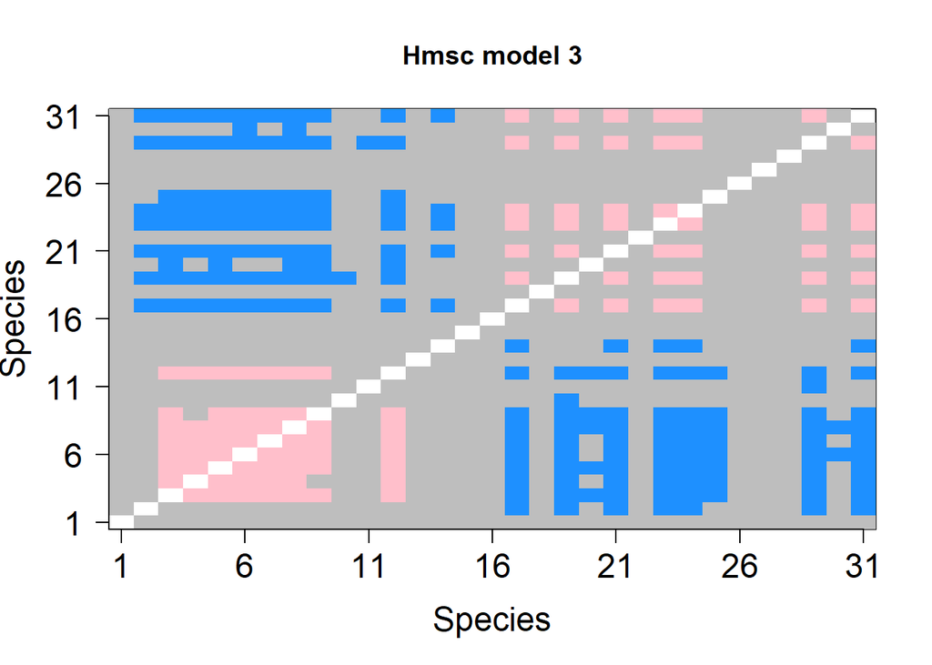

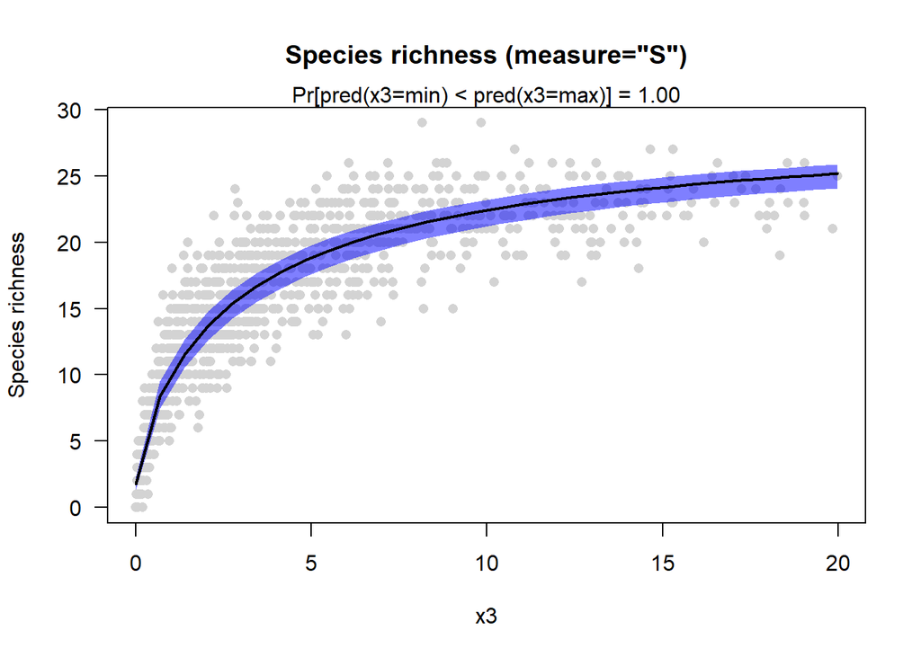

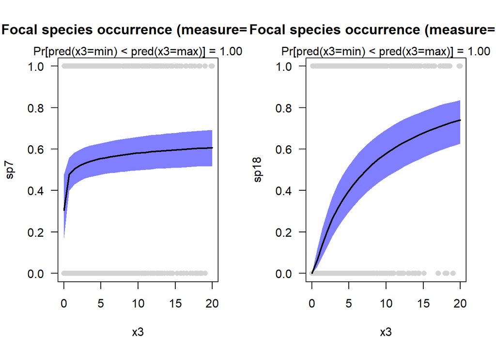

[output not shown]

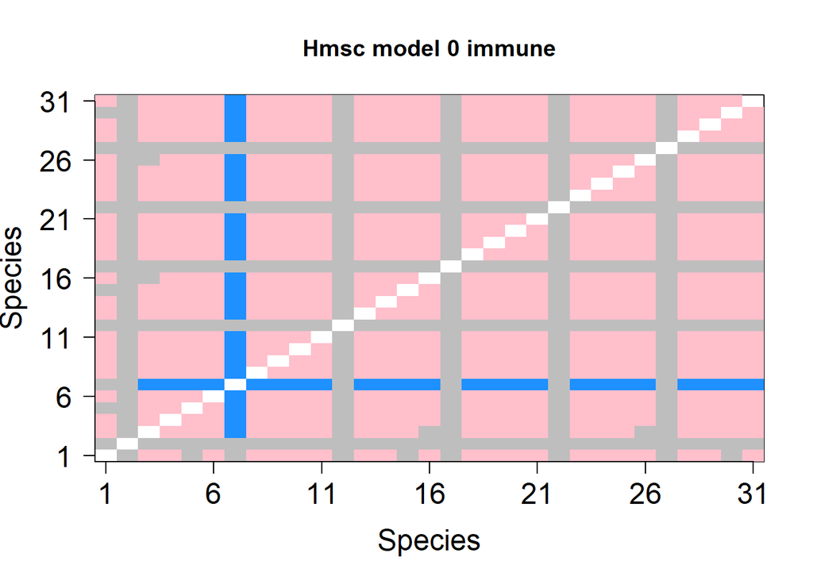

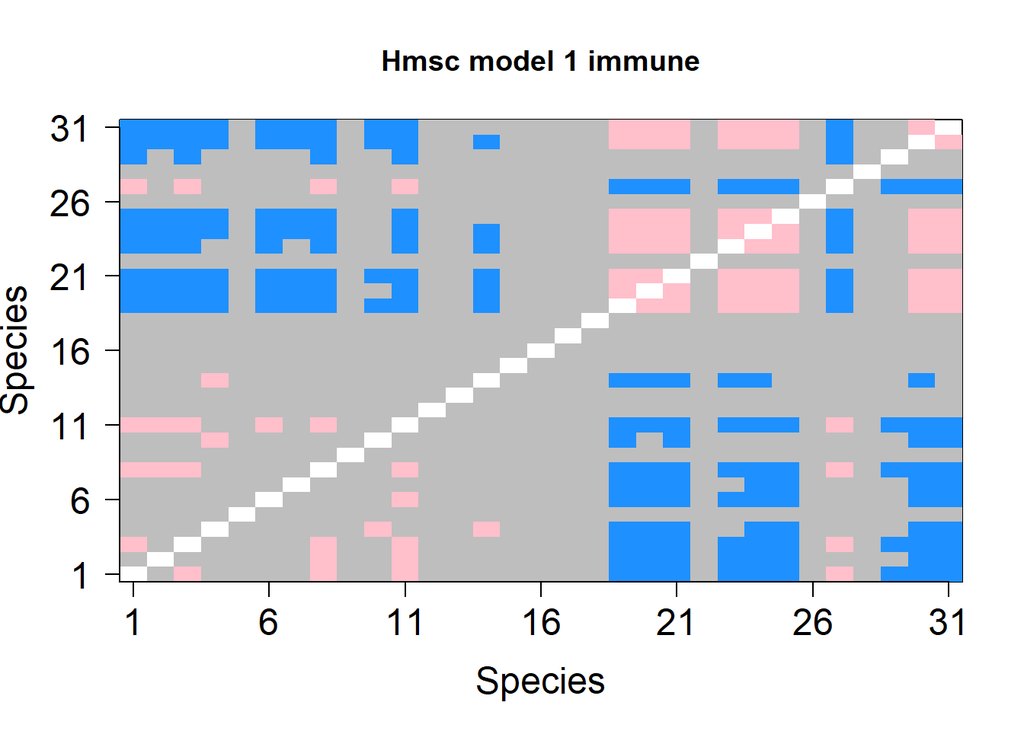

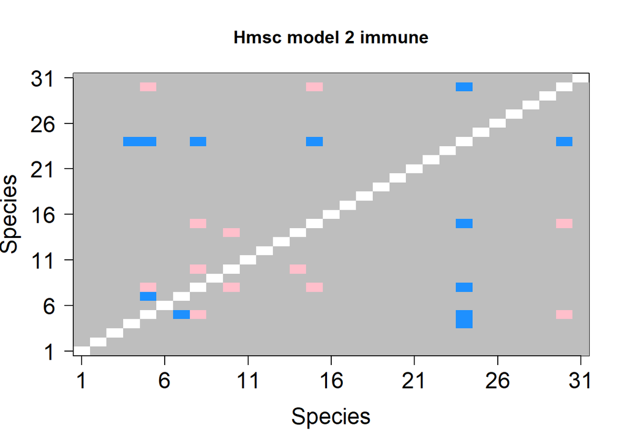

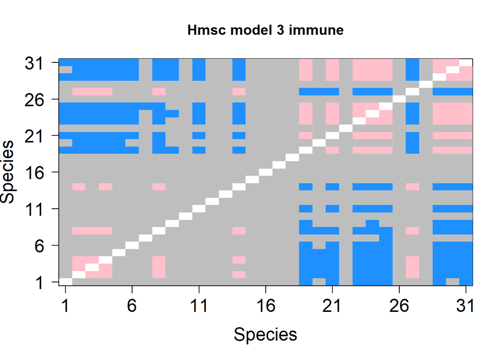

```r
#
# This code is run twice, once with immunity and once without
# only difference is that c etc. must be set first
#
for(hmscWithImmune in c(FALSE,TRUE))
{
  # recover the cached patch matrix and other relevant information
  if(hmscWithImmune)
  {
    c <- patchMatrixCacheImmune
    patchAge <- patchAgeCacheImmune
    m <- modelCacheImmune
    sTitleSuff <- " immune"
  }else{
    c <- patchMatrixCache
    patchAge <- patchAgeCache
    m <- modelCache
    sTitleSuff <- ""
  }
  ###########
  #### Prepare data for use with Hmsc
  ###########

  ## 1. c is the community matrix:
  colnames(c)<-paste("sp",1:nSpp,sep="")

  # 2. Environmental covariates:
  ## all patches are identical, so:
  # x1 is randomly varying around 1 (dummy variable)
  # x3 is actual patch age
  x=data.frame(x1=rnorm(nPatches,m=1,sd=0.1), x3=patchAge)

  ## 3. Species traits:
  # we take their "variance" (inverse of fastness)
  # dummy is a dummy trait
  t = data.frame(fastness=m$modelCalculations$vVariance, dummy=rnorm(nSpp,m=1,sd=0.1))

  ############
  ##### Run the four models
  ############

  #################
  ####### Model 0: naive co-occurrence analysis (sim2-like)
  #################

  ## we introduce a dummy random effect to facilitate the computation of residual associations
  studyDesign = data.frame(sites=as.factor(1:nPatches))
  rL = list()
  rL[['sites']] = HmscRandomLevel(units=unique(studyDesign$sites))

  m0 <- Hmsc(Y = c,
             XData=x,
             XFormula=~1,
             studyDesign= studyDesign,
             ranLevels=rL,
             distr="probit")
  set.seed(1)
  m0run = sampleMcmc(m0,
                     samples = samples,
                     thin = thin,
                     adaptNf = rep(ceiling(0.4*samples*thin),1),
                     transient = ceiling(0.5*samples*thin),
                     nChains = nChains,
                     nParallel = 1,
                     initPar = "fixed effects",
                     verbose=0)

  #################
  ####### Model 1: pseudo sim9 approach (with one latent factor)
  #################

  ## we introduce a dummy random effect to facilitate the computation of residual associations
  ## we further introduce a latent factor based on patch alpha diversity (requires NO additional information, and mimics sim9)
  spnb = apply(c,1,sum)
  studyDesign = data.frame(sites=as.factor(1:nPatches),spnb=as.factor(spnb))
  rL = list()
  rL[['sites']] = HmscRandomLevel(units=unique(studyDesign$sites))
  rL[['spnb']] = HmscRandomLevel(units=unique(spnb))

  m1 <- Hmsc(Y = c,
             XData=x,
             XFormula=~1,
             studyDesign = studyDesign,
             ranLevels=rL,
             distr="probit")
  set.seed(1)
  m1run = sampleMcmc(m1,
                     samples = samples,
                     thin = thin,
                     adaptNf = rep(ceiling(0.4*samples*thin),2),
                     transient = ceiling(0.5*samples*thin),
                     nChains = nChains,
                     nParallel = 1,
                     initPar = "fixed effects",
                     verbose=0)

  #################
  ####### Model 2: 'patch age as a covariate' approach
  #################

  ## we introduce a dummy random effect to facilitate the computation of residual associations
  ## we further introduce patch age as an explicit environmental covariate
  studyDesign = data.frame(sites=as.factor(1:nPatches))
  rL = list()
  rL[['sites']] = HmscRandomLevel(units=unique(studyDesign$sites))

  ## note: we use log(patch age) as a covariate since patch age is exponentially distributed
  m2 <- Hmsc(Y = c,
             XData=x,
             XFormula=~log(x3),
             studyDesign = studyDesign,
             ranLevels=rL,
             distr="probit")
  set.seed(1)
  m2run = sampleMcmc(m2,
                     samples = samples,
                     thin = thin,
                     adaptNf = rep(ceiling(0.4*samples*thin),1),
                     transient = ceiling(0.5*samples*thin),
                     nChains = nChains,
                     nParallel = 1,
                     initPar = "fixed effects",
                     verbose=0)

  #################
  ####### Model 2': 'patch richness as a covariate' approach (surrogate of actual patch age)
  #################

  ## we introduce a dummy random effect to facilitate the computation of residual associations
  ## we further introduce patch richness as an explicit environmental covariate
  studyDesign = data.frame(sites=as.factor(1:nPatches))
  rL = list()
  rL[['sites']] = HmscRandomLevel(units=unique(studyDesign$sites))
  spnb = apply(c,1,sum)
  x$div <- spnb

  m2p <- Hmsc(Y = c,
             XData=x,
             XFormula=~div,
             studyDesign = studyDesign,
             ranLevels=rL,
             distr="probit")
  set.seed(1)
  m2prun = sampleMcmc(m2p,
                     samples = samples,
                     thin = thin,
                     adaptNf = rep(ceiling(0.4*samples*thin),1),
                     transient = ceiling(0.5*samples*thin),
                     nChains = nChains,
                     nParallel = 1,
                     initPar = "fixed effects",
                     verbose=0)

  ############
  ##### Generate plots of the results of the model runs
  ############

  par(mfrow = c(1, 1))

  ########### Model 0

  supportLevel <- 1 - sigThresh

  OmegaCor0 = computeAssociations(m0run,
                                  thin=100,
                                  start=1)

  toPlot = ((OmegaCor0[[1]]$support>supportLevel) + (OmegaCor0[[1]]$support<(1-supportLevel))>0)*OmegaCor0[[1]]$mean
  for(i in 1:nSpp)
  {
    toPlot[i,i] <- NA
  }
  threeColours <- colorRampPalette(colors = c("dodgerblue","grey","pink"), space = "Lab")(3)

  image(x=1:nSpp,
        y=1:nSpp,
        z=toPlot[sppOrder,sppOrder],
        breaks=c(-1e10,-0.001,0.001,1e10),
        main=paste("Hmsc model 0",sTitleSuff,sep=""),
        xlab="Species",
        ylab="Species",
        xaxt="n",
        yaxt="n",
        col=threeColours,
        cex.lab=1.5,
        cex.axis=1.5)

  axis(1, seq(1,nSpp,5),las=1,cex.axis=1.5)
  axis(2, seq(1,nSpp,5),las=2,cex.axis=1.5)

  ########### Model 1

  OmegaCor1= computeAssociations(m1run,
                                 thin=100,
                                 start=1)

  toPlot = ((OmegaCor1[[1]]$support>supportLevel) + (OmegaCor1[[1]]$support<(1-supportLevel))>0)*OmegaCor1[[1]]$mean
  for(i in 1:nSpp)
  {
    toPlot[i,i] <- NA
  }
  threeColours <- colorRampPalette(colors = c("dodgerblue","grey","pink"), space = "Lab")(3)

  image(x=1:nSpp,
        y=1:nSpp,
        z=toPlot[sppOrder,sppOrder],
        breaks=c(-1e10,-0.001,0.001,1e10),
        main=paste("Hmsc model 1",sTitleSuff,sep=""),
        xlab="Species",
        ylab="Species",
        xaxt="n",
        yaxt="n",
        col=threeColours,
        cex.lab=1.5,
        cex.axis=1.5)
  axis(1, seq(1,nSpp,5),las=1,cex.axis=1.5)
  axis(2, seq(1,nSpp,5),las=2,cex.axis=1.5)

  ########### Model 2

  OmegaCor2= computeAssociations(m2run, thin=100, start=1)

  toPlot = ((OmegaCor2[[1]]$support>supportLevel) + (OmegaCor2[[1]]$support<(1-supportLevel))>0)*OmegaCor2[[1]]$mean
  for(i in 1:nSpp)
  {
    toPlot[i,i] <- NA
  }
  threeColours <- colorRampPalette(colors = c("dodgerblue","grey","pink"), space = "Lab")(3)

  image(x=1:nSpp,
        y=1:nSpp,
        z=toPlot[sppOrder,sppOrder],
        breaks=c(-1e10,-0.001,0.001,1e10),
        main=paste("Hmsc model 2",sTitleSuff,sep=""),
        xlab="Species",
        ylab="Species",
        xaxt="n",
        yaxt="n",
        col=threeColours,
        cex.lab=1.5,
        cex.axis=1.5)
  axis(1, seq(1,nSpp,5),las=1,cex.axis=1.5)
  axis(2, seq(1,nSpp,5),las=2,cex.axis=1.5)

  ########### Model 2'

  OmegaCor2p= computeAssociations(m2prun, thin=100, start=1)

  toPlot = ((OmegaCor2p[[1]]$support>supportLevel) + (OmegaCor2p[[1]]$support<(1-supportLevel))>0)*OmegaCor2p[[1]]$mean
  for(i in 1:nSpp)
  {
    toPlot[i,i] <- NA
  }
  threeColours <- colorRampPalette(colors = c("dodgerblue","grey","pink"), space = "Lab")(3)

  image(x=1:nSpp,
        y=1:nSpp,
        z=toPlot[sppOrder,sppOrder],
        breaks=c(-1e10,-0.001,0.001,1e10),
        main=paste("Hmsc model 3",sTitleSuff,sep=""),
        xlab="Species",
        ylab="Species",
        xaxt="n",
        yaxt="n",
        col=threeColours,
        cex.lab=1.5,
        cex.axis=1.5)
  axis(1, seq(1,nSpp,5),las=1,cex.axis=1.5)
  axis(2, seq(1,nSpp,5),las=2,cex.axis=1.5)


# for the case without immune species, also plot selected elements of the model fit for M2 (shown in Figure 6)
  if(!hmscWithImmune)
  {
    Gradient = constructGradient(m2run,
                                 focalVariable="x3",
                                 ngrid=30)
    predY = predict(m2run,
                    XData=Gradient$XDataNew,
                    studyDesign=Gradient$studyDesignNew,
                    ranLevels=Gradient$rLNew,
                    expected=TRUE)
    ## show species richness as a function of patch age

    plotGradient(m2run,
                 Gradient,
                 pred=predY,
                 measure="S",
                 las=1,
                 showData = TRUE,
                 main='Species richness (measure="S")')

    ## show occupancy per species
    ## we take one fast and one slow species
    lala=order(t$fastness)[c(1,31)]
    par(mfrow=c(1,2))
    for (ss in lala)
    {
      plotGradient(m2run,
                   Gradient,
                   pred=predY,
                   measure="Y",
                   index=ss,
                   las=1,
                   showData = TRUE,
                   main='Focal species occurrence (measure="Y")')
    }
  }
}
```

## Bibliography

Gotelli, Nicholas J., Edmund M. Hart, and Aaron M. Ellison. 2015. *EcoSimR: Null Model Analysis for Ecological Data*. https://doi.org/10.5281/zenodo.16522.

Ovaskainen, Otso, and Nerea Abrego. 2020. *Joint Species Distribution Modelling: With Applications in R*. Cambridge University Press.

Tikhonov, Gleb, Øystein H Opedal, Nerea Abrego, Aleksi Lehikoinen, Melinda MJ de Jonge, Jari Oksanen, and Otso Ovaskainen. 2020. “Joint Species Distribution Modelling with the R-Package Hmsc.” *Methods in Ecology and Evolution* 11 (3): 442–47.

Tikhonov, Gleb, Otso Ovaskainen, Jari Oksanen, Melinda de Jonge, Oystein Opedal, and Tad Dallas. 2021. *Hmsc: Hierarchical Model of Species Communities*. https://CRAN.R-project.org/package=Hmsc.